# Chica

## 05/05/20 ———————————————————————-

## 05/08/20 ———————————————————————-

By Friday: data in order, choose what algorithms to work on Next week: Work on our algorithms

Options:

- lm [ lm(covid cases ~ ., data = covid.eviction) ] supervised predictive linear numeric outcome
- k-means clustering unsupervised we can visualize clusters of similar data by distance
- knn supervised predictive can predict based on nearest data points (categorial predictor)
- decision trees supervised & unsupervised predictive: regression context: predict covid cases using features like eviction can use lm or other models as predictors classification: can just be used to visualize by similar features
- random forest supervised & unsupervised better tree models predictive classification
- lda unsupervised used for clustering: maxes distance between categories, mins distance within mostly just for grouping similar things
- pca unsupervised transforms data to new coordinate system which maxes variance between classes also mostly used just to make data easy to visualize by similarity/difference kind of difficult with our data, but we could look at just eviction similarities/differences and how that translates to covid
- splines fits a bunch of data with a squiggly line requires a more or less clear pattern, right? and continuous data on both axes?
- hierarchical clustering
- kernel smoothing supervised predictive estimates function as weighted avg of neighboring data (closer points weighted more)

## Unsupervised:

## Supervised:

## 05/07/20 ———————————————————————-

Libraries:

Load in data: (covid data for 4/30/20)

just in case it’s useful I’m gonna bring in death numbers.

Pop data we can use to control/adjust covid case and eviction filing rate data.

combine all of the covid data

filtering out non-county rows (“Statewide Unallocated”)

this is at a bunch of levels but not county I think so I’m going to get something at the county level. that way it can match our county-level covid data.

this is just the state-reported filing rate for several years. I’ll narrow it down to the most recent year.

Let’s see what the most recent year looks like:

Trying to figure out why there are more rows in covid than in eviction data. I guess we can just go with counties where we have both info for both. This leaves us with 26 states.

Create our mean benchmarks for evictions, deaths, and cases, all over pop. US total pop taken from https://www.census.gov/popclock/

I’m gonna base covid data on average of all states/counties including those that we don’t have evictiond data for.

Reorganize columns:

write new csv:

## 05/08/2020 ——————————————————————–

Add in other evictionlab variables:

```r
covid.eviction <- read_csv('covid_eviction.csv')

US.evictions <- read_csv('counties_us.csv')

eviction <- US.evictions

eviction.2016 <- eviction %>%
  filter(year == 2016)

length(unique(covid$countyFIPS))
length(unique(eviction.2016$GEOID))

str(eviction.2016$GEOID)
str(covid$countyFIPS)

eviction.2016$GEOID <- as.numeric(eviction.2016$GEOID)

covid.eviction <- inner_join(eviction.2016[, -c(3:5)], covid,
          by = c("GEOID" = "countyFIPS"))

# write_csv(covid.eviction, "covid_eviction2.csv")
```

## 05/14/2020 ——————————————————————–

# LM

```r
covid.eviction <- read_csv('covid_eviction2.csv')
```

simple lm: covid case rate against eviction filing rate

```r
summary(lm1)
```

```
Call:
lm(formula = county_covid_cases_rate ~ `eviction-filing-rate`,
    data = covid.eviction)

Residuals:
      Min        1Q    Median        3Q       Max
-0.004502 -0.001107 -0.000784 -0.000126  0.061371

Coefficients:
                        Estimate Std. Error t value Pr(>|t|)
(Intercept)            1.121e-03  7.062e-05  15.875  < 2e-16 ***
`eviction-filing-rate` 9.185e-05  1.213e-05   7.573 4.95e-14 ***
---
Signif. codes:  0 ‘***’ 0.001 ‘**’ 0.01 ‘*’ 0.05 ‘.’ 0.1 ‘ ’ 1

Residual standard error: 0.003119 on 2707 degrees of freedom
  (432 observations deleted due to missingness)
Multiple R-squared:  0.02075,   Adjusted R-squared:  0.02039
F-statistic: 57.36 on 1 and 2707 DF,  p-value: 4.955e-14
```

significant Rsq What other measures do we need to compare this to other models?

graph it to see what the slope looks like:

```r
library(ggplot2)
```

Are there outliers I need to remove?

```r
boxplot.stats(covid.eviction$`eviction-filing-rate`)$out
```

```
  [1]   9.30   9.75  18.15  16.08  14.64  15.67  19.18  10.10  13.29  15.32  12.33  16.49  12.79
 [14]  16.03  11.09  18.14  11.87  42.79  17.89   9.34  13.65   9.62   9.21  22.87  11.96  12.06
 [27]  12.40  15.96  18.97  11.02  22.17  30.11  12.36  10.71  12.69  15.51   9.43  16.92   9.95
 [40]  13.00  14.97  18.88  12.67  22.23  26.52  10.09  13.69  25.74  11.63  10.00  19.34   9.48
 [53]  12.45  12.63  12.06  16.35  16.43   9.25  11.43  17.31   9.10   9.69   9.73  10.46  11.08
 [66] 109.16  10.66  15.55   9.83  13.40   9.60  17.68  13.57  15.48   9.90  16.93  14.91  12.89
 [79]  12.65  20.43  17.85  19.23  13.25   9.85   9.15  10.71  10.32  19.05  12.17  10.23  10.61
 [92]  10.54  15.00   9.98  17.68  14.23  14.41  16.07  15.74  21.79  11.67  15.66  10.44   9.59
[105]  12.63  15.24   9.38  12.19  11.36  18.75  11.08  14.28  10.25  14.04  17.92  15.99  14.92
[118]  10.07  18.70  10.30  15.59  16.43  13.98   9.67  10.46  19.24  10.12  11.03  20.04   9.96
[131]  10.02  11.18   9.54  13.33  10.85   9.85  13.39  15.04  16.36  10.26  16.82  23.78  18.71
[144]  30.79  14.93   9.89  14.70  18.78  17.75  29.73  10.17  39.06  16.45  24.54  13.18  12.72
[157]  14.96  23.40  11.43  17.41  28.67  13.43  12.89  27.04  15.04  12.38  14.55  10.79   9.07
[170]  24.95  18.76  10.27   9.30  24.72  18.03  34.25  11.92  11.63  14.23  10.53  13.73  15.63
[183]  23.68  19.00   9.76  19.84  16.56  37.25  30.51   9.56  34.10  27.62  44.98  37.50  35.66
[196]  30.95  10.41  12.09  23.43  20.65  12.23  12.12  12.01
```

eh nevermind

Add controls for poverty rate:

```r
summary(lm2)
```

```
Call:
lm(formula = county_covid_cases_rate ~ `eviction-filing-rate` +
    `poverty-rate`, data = covid.eviction)

Residuals:
      Min        1Q    Median        3Q       Max
-0.004567 -0.001065 -0.000744 -0.000082  0.061060

Coefficients:
                        Estimate Std. Error t value Pr(>|t|)
(Intercept)            6.805e-04  1.439e-04   4.730 2.36e-06 ***
`eviction-filing-rate` 8.877e-05  1.213e-05   7.316 3.34e-13 ***
`poverty-rate`         3.739e-05  1.064e-05   3.513 0.000451 ***
---
Signif. codes:  0 ‘***’ 0.001 ‘**’ 0.01 ‘*’ 0.05 ‘.’ 0.1 ‘ ’ 1

Residual standard error: 0.003113 on 2706 degrees of freedom
  (432 observations deleted due to missingness)
Multiple R-squared:  0.02519,   Adjusted R-squared:  0.02447
F-statistic: 34.97 on 2 and 2706 DF,  p-value: 1.015e-15
```

Adjusted R-sq increased all variables significant

Try with additional income variables:

```r
summary(lm3)
```

```
Call:
lm(formula = county_covid_cases_rate ~ `eviction-filing-rate` +
    `poverty-rate` + `renter-occupied-households`, data = covid.eviction)

Residuals:
      Min        1Q    Median        3Q       Max
-0.013331 -0.001019 -0.000712 -0.000068  0.061115

Coefficients:
                              Estimate Std. Error t value Pr(>|t|)
(Intercept)                  5.992e-04  1.428e-04   4.196 2.80e-05 ***
`eviction-filing-rate`       7.446e-05  1.216e-05   6.124 1.05e-09 ***
`poverty-rate`               3.832e-05  1.054e-05   3.637 0.000281 ***
`renter-occupied-households` 8.061e-09  1.068e-09   7.546 6.08e-14 ***
---
Signif. codes:  0 ‘***’ 0.001 ‘**’ 0.01 ‘*’ 0.05 ‘.’ 0.1 ‘ ’ 1

Residual standard error: 0.003081 on 2705 degrees of freedom
  (432 observations deleted due to missingness)
Multiple R-squared:  0.04529,   Adjusted R-squared:  0.04423
F-statistic: 42.78 on 3 and 2705 DF,  p-value: < 2.2e-16
```

Adjusted R squared just doubled. Is renter occupied households just increasing bc its not a rate? (greater pop -> greater renter pop)

Will try control:

```r
summary(lm4)
```

```
Call:
lm(formula = county_covid_cases_rate ~ `eviction-filing-rate` +
    `poverty-rate` + renter_rate, data = covid.eviction2)

Residuals:
      Min        1Q    Median        3Q       Max
-0.005020 -0.001077 -0.000729 -0.000071  0.061263

Coefficients:
                        Estimate Std. Error t value Pr(>|t|)
(Intercept)            1.352e-04  2.385e-04   0.567  0.57106
`eviction-filing-rate` 8.387e-05  1.224e-05   6.853 8.92e-12 ***
`poverty-rate`         3.110e-05  1.085e-05   2.865  0.00420 **
renter_rate            5.370e-03  1.875e-03   2.864  0.00422 **
---
Signif. codes:  0 ‘***’ 0.001 ‘**’ 0.01 ‘*’ 0.05 ‘.’ 0.1 ‘ ’ 1

Residual standard error: 0.003108 on 2705 degrees of freedom
  (432 observations deleted due to missingness)
Multiple R-squared:  0.02814,   Adjusted R-squared:  0.02706
F-statistic: 26.11 on 3 and 2705 DF,  p-value: < 2.2e-16
```

decreases Adj r-sq but still higher than simple or just eviction filing and poverty rate lm. will go with this.

Add more variables:

```r
summary(lm5)
```

```
Call:
lm(formula = county_covid_cases_rate ~ `eviction-filing-rate` +
    `poverty-rate` + renter_rate + `rent-burden`, data = covid.eviction2)

Residuals:
      Min        1Q    Median        3Q       Max
-0.004785 -0.001078 -0.000703 -0.000081  0.061213

Coefficients:
                         Estimate Std. Error t value Pr(>|t|)
(Intercept)            -7.760e-04  4.112e-04  -1.887  0.05926 .
`eviction-filing-rate`  7.535e-05  1.262e-05   5.972 2.66e-09 ***
`poverty-rate`          1.997e-05  1.159e-05   1.723  0.08503 .
renter_rate             4.984e-03  1.878e-03   2.653  0.00802 **
`rent-burden`           3.944e-05  1.451e-05   2.718  0.00660 **
---
Signif. codes:  0 ‘***’ 0.001 ‘**’ 0.01 ‘*’ 0.05 ‘.’ 0.1 ‘ ’ 1

Residual standard error: 0.003105 on 2704 degrees of freedom
  (432 observations deleted due to missingness)
Multiple R-squared:  0.03079,   Adjusted R-squared:  0.02936
F-statistic: 21.47 on 4 and 2704 DF,  p-value: < 2.2e-16
```

Rent burden seems to make poverty rate insignificant. Prob bc they kind of represent the same thing. Try taking out poverty rate:

```r
summary(lm6)
```

```
Call:
lm(formula = county_covid_cases_rate ~ `eviction-filing-rate` +
    renter_rate + `rent-burden`, data = covid.eviction2)

Residuals:
      Min        1Q    Median        3Q       Max
-0.004648 -0.001081 -0.000705 -0.000095  0.061364

Coefficients:
                         Estimate Std. Error t value Pr(>|t|)
(Intercept)            -8.446e-04  4.095e-04  -2.063 0.039222 *
`eviction-filing-rate`  7.427e-05  1.261e-05   5.891 4.32e-09 ***
renter_rate             5.508e-03  1.854e-03   2.971 0.002999 **
`rent-burden`           4.828e-05  1.358e-05   3.556 0.000384 ***
---
Signif. codes:  0 ‘***’ 0.001 ‘**’ 0.01 ‘*’ 0.05 ‘.’ 0.1 ‘ ’ 1

Residual standard error: 0.003106 on 2705 degrees of freedom
  (432 observations deleted due to missingness)
Multiple R-squared:  0.02973,   Adjusted R-squared:  0.02865
F-statistic: 27.62 on 3 and 2705 DF,  p-value: < 2.2e-16
```

Other demo variables pct-af-am:

```r
summary(lm7)
```

```
Call:
lm(formula = county_covid_cases_rate ~ `eviction-filing-rate` +
    renter_rate + `rent-burden` + `pct-af-am`, data = covid.eviction2)

Residuals:
      Min        1Q    Median        3Q       Max
-0.005271 -0.000944 -0.000664 -0.000102  0.060401

Coefficients:
                        Estimate Std. Error t value Pr(>|t|)
(Intercept)            6.368e-05  4.205e-04   0.151  0.87964
`eviction-filing-rate` 3.933e-05  1.321e-05   2.977  0.00293 **
renter_rate            3.088e-03  1.858e-03   1.662  0.09663 .
`rent-burden`          1.860e-05  1.393e-05   1.335  0.18188
`pct-af-am`            3.871e-05  4.851e-06   7.979 2.16e-15 ***
---
Signif. codes:  0 ‘***’ 0.001 ‘**’ 0.01 ‘*’ 0.05 ‘.’ 0.1 ‘ ’ 1

Residual standard error: 0.003071 on 2704 degrees of freedom
  (432 observations deleted due to missingness)
Multiple R-squared:  0.05204,   Adjusted R-squared:  0.05064
F-statistic: 37.11 on 4 and 2704 DF,  p-value: < 2.2e-16
```

drastically increases adj r-sq, and rent-related variables become insignificant.

Remove those rent variables:

```r
summary(lm8)
```

```
Call:
lm(formula = county_covid_cases_rate ~ `eviction-filing-rate` +
    `pct-af-am`, data = covid.eviction2)

Residuals:
      Min        1Q    Median        3Q       Max
-0.005099 -0.000932 -0.000675 -0.000124  0.060290

Coefficients:
                        Estimate Std. Error t value Pr(>|t|)
(Intercept)            9.160e-04  7.306e-05  12.537  < 2e-16 ***
`eviction-filing-rate` 4.318e-05  1.307e-05   3.304 0.000967 ***
`pct-af-am`            4.208e-05  4.587e-06   9.175  < 2e-16 ***
---
Signif. codes:  0 ‘***’ 0.001 ‘**’ 0.01 ‘*’ 0.05 ‘.’ 0.1 ‘ ’ 1

Residual standard error: 0.003072 on 2706 degrees of freedom
  (432 observations deleted due to missingness)
Multiple R-squared:  0.05029,   Adjusted R-squared:  0.04959
F-statistic: 71.65 on 2 and 2706 DF,  p-value: < 2.2e-16
```

adj R-sq decreases slightly but i think the model is better.

Add all other race-related variables:

```r
summary(lm9)
```

```
Call:
lm(formula = county_covid_cases_rate ~ `eviction-filing-rate` +
    `pct-af-am` + `pct-hispanic` + `pct-am-ind` + `pct-white` +
    `pct-asian` + `pct-nh-pi`, data = covid.eviction2)

Residuals:
      Min        1Q    Median        3Q       Max
-0.008130 -0.000861 -0.000532  0.000014  0.060424

Coefficients:
                         Estimate Std. Error t value Pr(>|t|)
(Intercept)            -1.017e-02  3.639e-03  -2.794 0.005244 **
`eviction-filing-rate`  3.113e-05  1.308e-05   2.379 0.017432 *
`pct-af-am`             1.519e-04  3.673e-05   4.136 3.64e-05 ***
`pct-hispanic`          1.299e-04  3.687e-05   3.523 0.000434 ***
`pct-am-ind`            1.095e-04  4.092e-05   2.676 0.007503 **
`pct-white`             1.091e-04  3.698e-05   2.949 0.003215 **
`pct-asian`             3.282e-04  4.954e-05   6.626 4.15e-11 ***
`pct-nh-pi`            -1.397e-04  9.119e-05  -1.532 0.125583
---
Signif. codes:  0 ‘***’ 0.001 ‘**’ 0.01 ‘*’ 0.05 ‘.’ 0.1 ‘ ’ 1

Residual standard error: 0.003012 on 2701 degrees of freedom
  (432 observations deleted due to missingness)
Multiple R-squared:  0.0887,    Adjusted R-squared:  0.08633
F-statistic: 37.55 on 7 and 2701 DF,  p-value: < 2.2e-16
```

Adj r-sq goes up but significance changes.

Remove insignificant pct-nh-pi:

```r
lm10 <- lm(county_covid_cases_rate ~ `eviction-filing-rate` + `pct-af-am` + `pct-hispanic` + `pct-am-ind` + `pct-white` + `pct-asian`,
          data = covid.eviction2)
summary(lm10)
```

```
Call:
lm(formula = county_covid_cases_rate ~ `eviction-filing-rate` +
    `pct-af-am` + `pct-hispanic` + `pct-am-ind` + `pct-white` +
    `pct-asian`, data = covid.eviction2)

Residuals:
      Min        1Q    Median        3Q       Max
-0.008129 -0.000870 -0.000537  0.000018  0.060404

Coefficients:
                         Estimate Std. Error t value Pr(>|t|)
(Intercept)            -1.284e-02  3.195e-03  -4.018 6.03e-05 ***
`eviction-filing-rate`  3.330e-05  1.301e-05   2.560 0.010530 *
`pct-af-am`             1.788e-04  3.229e-05   5.536 3.39e-08 ***
`pct-hispanic`          1.569e-04  3.237e-05   4.848 1.32e-06 ***
`pct-am-ind`            1.386e-04  3.626e-05   3.822 0.000136 ***
`pct-white`             1.362e-04  3.248e-05   4.193 2.84e-05 ***
`pct-asian`             3.494e-04  4.759e-05   7.341 2.79e-13 ***
---
Signif. codes:  0 ‘***’ 0.001 ‘**’ 0.01 ‘*’ 0.05 ‘.’ 0.1 ‘ ’ 1

Residual standard error: 0.003013 on 2702 degrees of freedom
  (432 observations deleted due to missingness)
Multiple R-squared:  0.0879,    Adjusted R-squared:  0.08588
F-statistic:  43.4 on 6 and 2702 DF,  p-value: < 2.2e-16
```

All race percentages are significant, but they’re also all positive, which means being any race makes for greater covid case rates. Some are higher than others, and mostly follow patterns as predicted. I’m going to try anova to see what it comes with.

ANOVA:

```r
aov1 <- aov(county_covid_cases_rate ~ `eviction-filing-rate` + `pct-af-am` + `pct-hispanic` + `pct-am-ind` + `pct-white` + `pct-asian`,
          data = covid.eviction2)
summary(aov1)
```

[output not shown]

remove pct-am-ind:

```r
aov2 <- aov(county_covid_cases_rate ~ `eviction-filing-rate` + `pct-af-am` + `pct-hispanic` + `pct-white` + `pct-asian`,
          data = covid.eviction2)
summary(aov2)
```

[output not shown]

remove pct white:

```r
summary(aov3)
```

```
                         Df   Sum Sq   Mean Sq F value   Pr(>F)
`eviction-filing-rate`    1 0.000558 0.0005580   61.09 7.75e-15 ***
`pct-af-am`               1 0.000794 0.0007945   86.97  < 2e-16 ***
`pct-hispanic`            1 0.000342 0.0003420   37.44 1.08e-09 ***
`pct-asian`               1 0.000499 0.0004994   54.67 1.89e-13 ***
Residuals              2704 0.024699 0.0000091
---
Signif. codes:  0 ‘***’ 0.001 ‘**’ 0.01 ‘*’ 0.05 ‘.’ 0.1 ‘ ’ 1
432 observations deleted due to missingness
```

New long model:

```r
summary(lm11)
```

```
Call:
lm(formula = county_covid_cases_rate ~ `eviction-filing-rate` +
    `pct-af-am` + `pct-hispanic` + `pct-asian`, data = covid.eviction2)

Residuals:
      Min        1Q    Median        3Q       Max
-0.007445 -0.000884 -0.000537 -0.000014  0.060502

Coefficients:
                        Estimate Std. Error t value Pr(>|t|)
(Intercept)            5.336e-04  8.469e-05   6.301 3.44e-10 ***
`eviction-filing-rate` 2.945e-05  1.299e-05   2.267   0.0235 *
`pct-af-am`            4.507e-05  4.529e-06   9.951  < 2e-16 ***
`pct-hispanic`         2.285e-05  4.635e-06   4.930 8.72e-07 ***
`pct-asian`            1.755e-04  2.373e-05   7.394 1.89e-13 ***
---
Signif. codes:  0 ‘***’ 0.001 ‘**’ 0.01 ‘*’ 0.05 ‘.’ 0.1 ‘ ’ 1

Residual standard error: 0.003022 on 2704 degrees of freedom
  (432 observations deleted due to missingness)
Multiple R-squared:  0.08158,   Adjusted R-squared:  0.08022
F-statistic: 60.04 on 4 and 2704 DF,  p-value: < 2.2e-16
```

Super high adj-rq (comparatively) All variables significant, but eviction becomes less significant shows that race seems to matter more than anything.

Try interaction?

```r
summary(aov4)
```

```
                                     Df   Sum Sq   Mean Sq F value   Pr(>F)
`eviction-filing-rate`                1 0.000558 0.0005580   61.51 6.28e-15 ***
`pct-af-am`                           1 0.000794 0.0007945   87.58  < 2e-16 ***
`pct-hispanic`                        1 0.000342 0.0003420   37.70 9.46e-10 ***
`pct-asian`                           1 0.000499 0.0004994   55.05 1.56e-13 ***
`eviction-filing-rate`:`pct-af-am`    1 0.000179 0.0001791   19.74 9.22e-06 ***
Residuals                          2703 0.024520 0.0000091
---
Signif. codes:  0 ‘***’ 0.001 ‘**’ 0.01 ‘*’ 0.05 ‘.’ 0.1 ‘ ’ 1
432 observations deleted due to missingness
```

Interaction is significant. Adding it to model:

```r
summary(lm12)
```

```
Call:
lm(formula = county_covid_cases_rate ~ `eviction-filing-rate` *
    `pct-af-am` + `pct-hispanic` + `pct-asian`, data = covid.eviction2)

Residuals:
      Min        1Q    Median        3Q       Max
-0.007022 -0.000907 -0.000484  0.000015  0.060454

Coefficients:
                                     Estimate Std. Error t value Pr(>|t|)
(Intercept)                         3.603e-04  9.298e-05   3.875 0.000109 ***
`eviction-filing-rate`              1.073e-04  2.179e-05   4.925 8.93e-07 ***
`pct-af-am`                         5.214e-05  4.786e-06  10.895  < 2e-16 ***
`pct-hispanic`                      2.399e-05  4.626e-06   5.185 2.32e-07 ***
`pct-asian`                         1.675e-04  2.372e-05   7.061 2.09e-12 ***
`eviction-filing-rate`:`pct-af-am` -2.323e-06  5.228e-07  -4.443 9.22e-06 ***
---
Signif. codes:  0 ‘***’ 0.001 ‘**’ 0.01 ‘*’ 0.05 ‘.’ 0.1 ‘ ’ 1

Residual standard error: 0.003012 on 2703 degrees of freedom
  (432 observations deleted due to missingness)
Multiple R-squared:  0.08824,   Adjusted R-squared:  0.08655
F-statistic: 52.32 on 5 and 2703 DF,  p-value: < 2.2e-16
```

adj r-sq Increases significantly, all variables highly significant. Shows that as pct-af-am increases, eviction filing rate matters less. Magnitude of coefficients: 1) pct-asian 2) eviction-filing-rate 3) pct-af-am 4) pct-hispanic 5) eviction-filing-rate:pct-af-am

# KNN

```r
knn1 <- knn(na.omit(covid.eviction[, c(11, 21, 37)]), grid3, cl = covid.eviction$county_covid_cases_rate, k = 1)
```

```
Error in knn(na.omit(covid.eviction[, c(11, 21, 37)]), grid3, cl = covid.eviction$county_covid_cases_rate,  :
  no missing values are allowed
```

This grid situation isn’t working. trying to use a random subset of original data as test:

```r
for(k in 1:20){

  for(i in 1:nrow(ce)){

    train <- covid.eviction2[-i,]
    test <- covid.eviction2[i,]

    prediction <- knn(train = train %>%
                        select(`pct-af-am`, `eviction-filing-rate`),
                      test = test %>%
                        select(`pct-af-am`, `eviction-filing-rate`),
                      train$covidCases_greater_state,
                      k)

    store[i] <- ifelse(prediction == covid.eviction2$covidCases_greater_state[i],
                       1,
                       0)

  }

  accuracy[k] <- mean(store)

    }
```

Now that I’ve found accuracies, will try to graph it using best k:

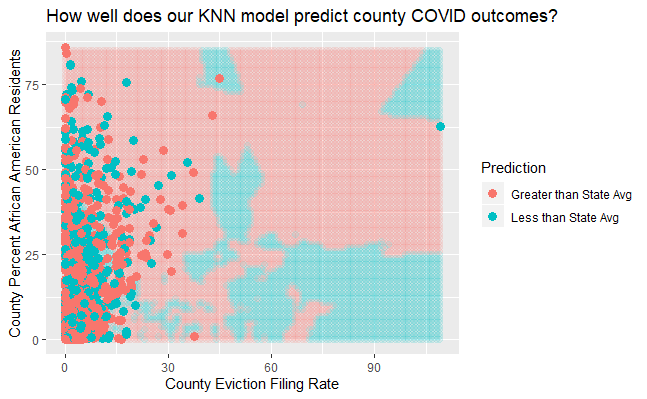

Repeat but normalized this time:

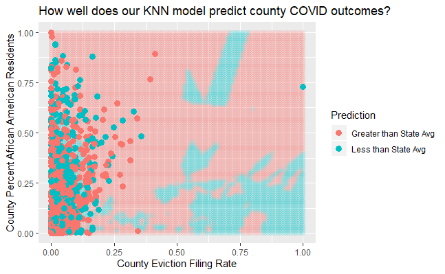

Repeat for deaths:

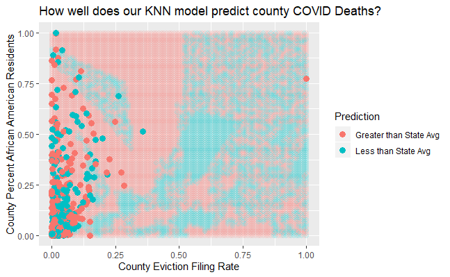

```r
confusionMatrix(train3.test$prediction, test.cl$covidDeaths_greater_state)
```

```
Confusion Matrix and Statistics

          Reference
Prediction  0  1
         0 21 13
         1 13  8

               Accuracy : 0.5273
                 95% CI : (0.388, 0.6635)
    No Information Rate : 0.6182
    P-Value [Acc > NIR] : 0.9352

                  Kappa : -0.0014

 Mcnemar's Test P-Value : 1.0000

            Sensitivity : 0.6176
            Specificity : 0.3810
         Pos Pred Value : 0.6176
         Neg Pred Value : 0.3810
             Prevalence : 0.6182
         Detection Rate : 0.3818
   Detection Prevalence : 0.6182
      Balanced Accuracy : 0.4993

       'Positive' Class : 0
```